# Fisheries Inventory, Trout Data, at Rocky Mountain National Park 2021–2022

# Fisheries Inventory, Trout Data, at Rocky Mountain National Park 2021–2022

Sergio E. Sagastume

2025-05-08

## Introduction

This project analyzes trout population data collected from Rocky Mountain National Park between 2021 and 2022. It aims to understand how fire events may have impacted trout population structure, abundance, and associated aquatic ecosystems.

## Scenario

As an aspiring data analyst contributing to wildlife conservation and monitoring initiatives, I am exploring data collected by the National Park Service. This case study focuses on the ecological effects of recent wildfires, specifically the 2020 Cameron Peak and East Troublesome fires, on fish populations.

## Prepare

**Data Source**: National Park Service. *Fisheries Inventory, Trout Data, at Rocky Mountain National Park 2021–2022*. Retrieved from catalog.data.gov.

```r
# Load data files (replace with your paths if necessary)
ROMOFish_TroutData_SurveyEvent <- read_csv("Wildfire Impact on Trout/ROMOFish_TroutData_SurveyEvent.csv")
ROMOFish_TroutData_Occurrence <- read_csv("Wildfire Impact on Trout/ROMOFish_TroutData_Occurrence.csv")
ROMOFish_TroutData_Taxon <- read_csv("Wildfire Impact on Trout/ROMOFish_TroutData_Taxon.csv")
```

## Process

```r
# Prepare and clean data
ROMOFish_TroutData_SurveyEvent <- ROMOFish_TroutData_SurveyEvent %>%
  mutate(eventDate = ymd(startDate), year = year(eventDate))

trout_data <- ROMOFish_TroutData_Occurrence %>%
  left_join(ROMOFish_TroutData_SurveyEvent, by = "eventID") %>%
  left_join(ROMOFish_TroutData_Taxon, by = "taxonID")

# Filter valid biological data
trout_data_clean <- trout_data %>%
  filter(!is.na(length) & !is.na(mass) & length > 0 & mass > 0) %>%
  mutate(length_category = cut(length,
                               breaks = c(0, 100, 200, 300, 400),
                               labels = c("0-100mm", "101-200mm", "201-300mm", "301-400mm"),
                               right = FALSE))
```

## Analyze

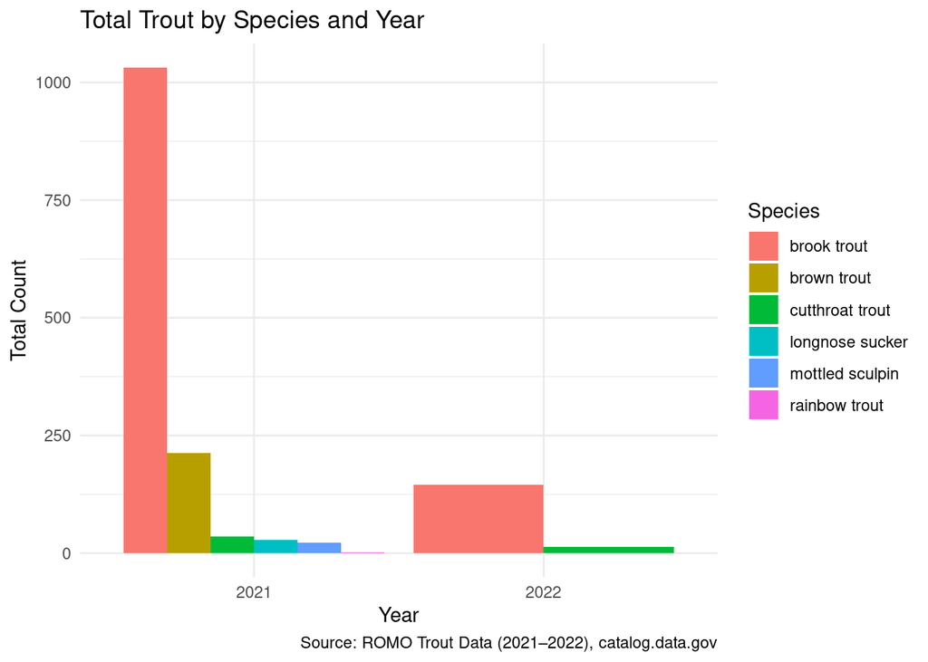

```r
# Trout count by species and year
trout_summary <- trout_data_clean %>%
  group_by(vernacularName, year) %>%
  summarise(total_trout = sum(individualCount, na.rm = TRUE), .groups = "drop")

# Visualization
ggplot(trout_summary, aes(x = factor(year), y = total_trout, fill = vernacularName)) +
  geom_col(position = "dodge") +
  labs(title = "Total Trout by Species and Year",
       x = "Year",
       y = "Total Count",
       fill = "Species",
       caption = "Source: ROMO Trout Data (2021–2022), catalog.data.gov") +
  theme_minimal()
```

## Share

This report presents trout population trends and visual information following the wildfires. The data is visualized using bar charts and summarized in tables, allowing stakeholders to assess the recovery status of aquatic species.

## Act

```r
# Highlight significant observations
significant_changes <- trout_summary %>%
  pivot_wider(names_from = year, values_from = total_trout, values_fill = 0) %>%
  mutate(change = `2022` - `2021`,
         trend = case_when(
           change > 0 ~ "Increase",
           change < 0 ~ "Decrease",
           TRUE ~ "No Change"
         ))

significant_changes
```

```
## # A tibble: 6 × 5
##   vernacularName  `2021` `2022` change trend
##   <chr>            <dbl>  <dbl>  <dbl> <chr>
## 1 brook trout       1031    145   -886 Decrease
## 2 brown trout        213      0   -213 Decrease
## 3 cutthroat trout     35     14    -21 Decrease
## 4 longnose sucker     28      0    -28 Decrease
## 5 mottled sculpin     22      0    -22 Decrease
## 6 rainbow trout        2      0     -2 Decrease
```

## Recommendations

1. **Increase Monitoring Frequency**: Continue yearly sampling to detect ecological changes.
2. **Focus Restoration Efforts**: Allocate conservation resources to sites where trout numbers are declining.
3. **Improve Public Engagement**: Share simplified versions of findings with local communities and visitors.
4. **Protect Sensitive Habitats**: Use this data to identify and protect habitats supporting at-risk trout species.